# COSMO rMATS initial analysis

Shay Iyer

2025-07-15

Group 1: Basal Group 2: TGFB-treated

# Maser

## Maser data pre-processing

## Basic plots

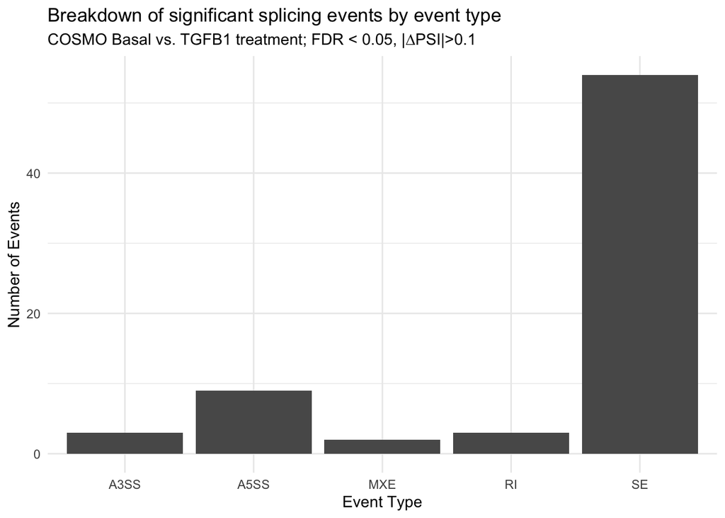

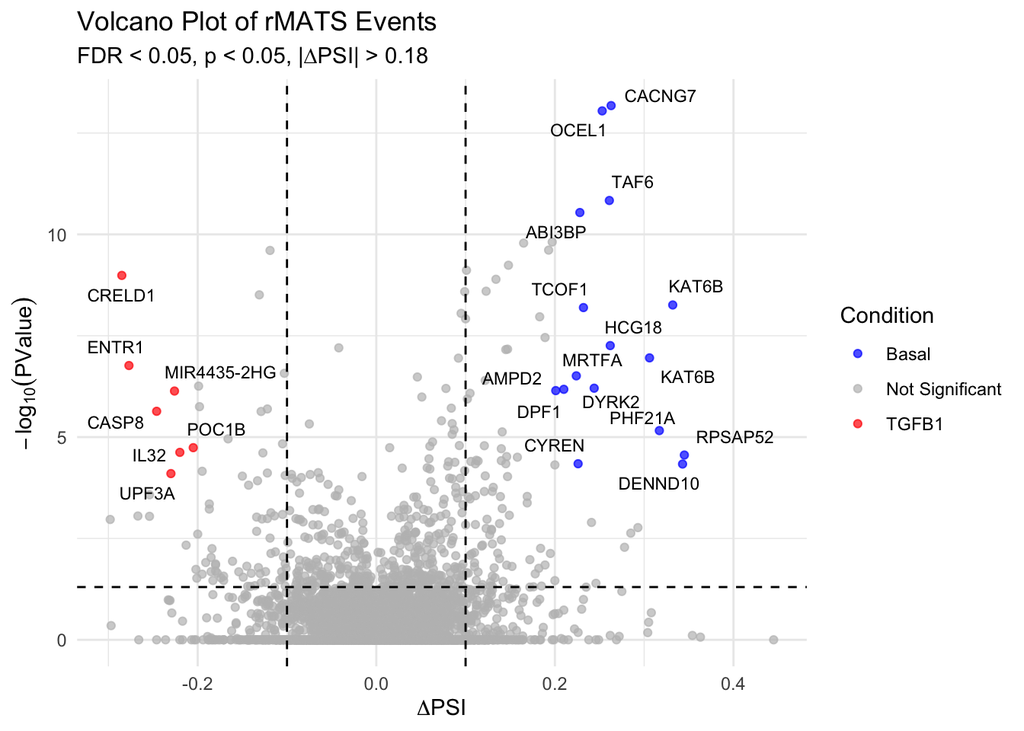

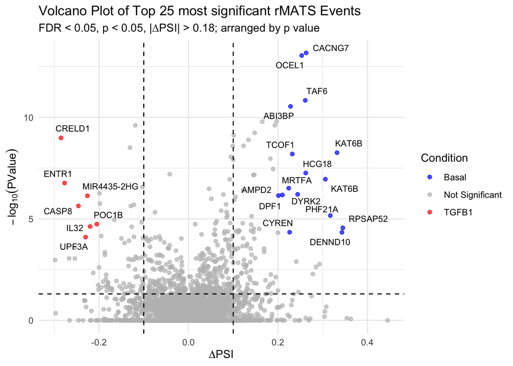

## Specific splicing events

> Genes from top events implicated in VSMC transitions/atherosclerosis, as identified by CellGPT 4o
- FHOD1: [Novel signaling axis of FHOD1-RNF213-Col1α/Col3α in the pathogenesis of hypertension-induced tunica media thickening](https://www.sciencedirect.com/science/article/pii/S0022282823001141), [Formin homology domain-containing protein 1 regulates smooth muscle cell phenotype](https://pubmed.ncbi.nlm.nih.gov/21106951/)
- STAT6: [“The downstream network of STAT6 in promoting vascular smooth muscle cell phenotypic switch and neointimal formation”](https://onlinelibrary.wiley.com/doi/full/10.1002/cbin.12056)
- MRTFA: [Signaling Mechanisms That Regulate Smooth Muscle Cell Differentiation](https://pmc.ncbi.nlm.nih.gov/articles/PMC3141215/) (this also mentions FHOD1), [A Novel Role of Brg1 in the Regulation of SRF/MRTFA-dependent Smooth Muscle-specific Gene Expression](https://www.sciencedirect.com/science/article/pii/S0021925820746466?via%3Dihub)
- SRGAP1: [H3K4 di-methylation governs smooth muscle lineage identity and promotes vascular homeostasis by restraining plasticity (Fig 8c)](https://pmc.ncbi.nlm.nih.gov/articles/PMC8567421/)
- IL32: [“Clinical Implications of IL-32, IL-34 and IL-37 in Atherosclerosis: Speculative Role in Cardiovascular Manifestations of COVID-19”](https://pmc.ncbi.nlm.nih.gov/articles/PMC8377289/?utm_source=chatgpt.com)
- DDIT3 (aka CHOP): [CHOP Increases TRIB3-Dependent miR-208 Expression to Potentiate Vascular Smooth Muscle Cell Proliferation and Migration by Downregulating TIMP3 in Atherosclerosis](https://pubmed.ncbi.nlm.nih.gov/33856595/)

```
## [1] "------FHOD1------"
```

```
## [1] "------STAT6------"
```

```
## [1] "------MRTFA------"
```

```
## [1] "------SRGAP1------"
```

```
## [1] "------IL32------"
```

```
## [1] "------DDIT/CHOP------"
```

```
## [[1]]
## A Maser object with 1 splicing events.
##
## Samples description:
## Label=Basal     n=12 replicates
## Label=TGFB1     n=12 replicates
##
## Splicing events:
## A3SS.......... 0 events
## A5SS.......... 0 events
## SE.......... 1 events
## RI.......... 0 events
## MXE.......... 0 events
##
## [[2]]
## A Maser object with 3 splicing events.
##
## Samples description:
## Label=Basal     n=12 replicates
## Label=TGFB1     n=12 replicates
##
## Splicing events:
## A3SS.......... 0 events
## A5SS.......... 1 events
## SE.......... 2 events
## RI.......... 0 events
## MXE.......... 0 events
##
## [[3]]
## A Maser object with 1 splicing events.
##
## Samples description:
## Label=Basal     n=12 replicates
## Label=TGFB1     n=12 replicates
##
## Splicing events:
## A3SS.......... 0 events
## A5SS.......... 0 events
## SE.......... 1 events
## RI.......... 0 events
```

[output cut: 28 more lines]

```
## MXE.......... 0 events
##
## [[6]]
## A Maser object with 1 splicing events.
##
## Samples description:
## Label=Basal     n=12 replicates
## Label=TGFB1     n=12 replicates
##
## Splicing events:
## A3SS.......... 0 events
## A5SS.......... 0 events
## SE.......... 0 events
## RI.......... 1 events
## MXE.......... 0 events
```

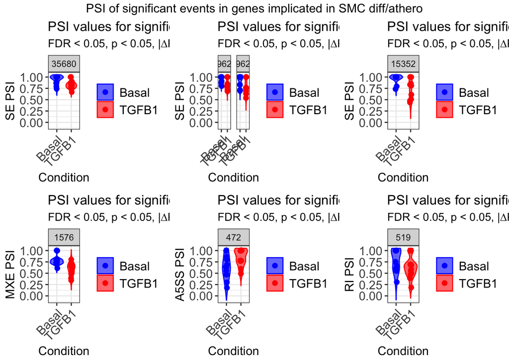

Additional to look into - RNF111 https://www.sciencedirect.com/science/article/pii/S1535947621001456?via%3Dihub - RALGDS https://pubmed.ncbi.nlm.nih.gov/12767920/ - KIDINS220 https://www.nature.com/articles/cddis2011108 - APBB2

```
##  [1] "GFOD3P"    "RNF111"    "DDIT3"     "RALGDS"    "KIDINS220" "PUM1"
##  [7] "PRKAG2"    "WASHC3"    "PRR13"     "APBB2"     "PRR13"     "MOK"
## [13] "ARHGAP5"   "ARFGEF2"
```